# Step-by-step guide to the MO-Coxmos pipeline

## Add patient to density plot

Additionally, the new observation can be added to the density and histogram plots that the model has computed. While this function can be useful in visualizing the results, it is important to note that no definitive conclusions can be drawn from these types of plots alone. They serve as an additional means of viewing the predictive values for the new patient (“lp”, “risk”, “expected”, “terms”, “survival”) in relation to the training dataset and its histogram or density plot, along with the events or censored patients.

```r
pat_density <- plot_observation.eventDensity(observation = new_pat,
                                             model = lst_models$`SB.sPLS-DRCOX`,
                                             time = NULL,
                                             type = "lp")
```

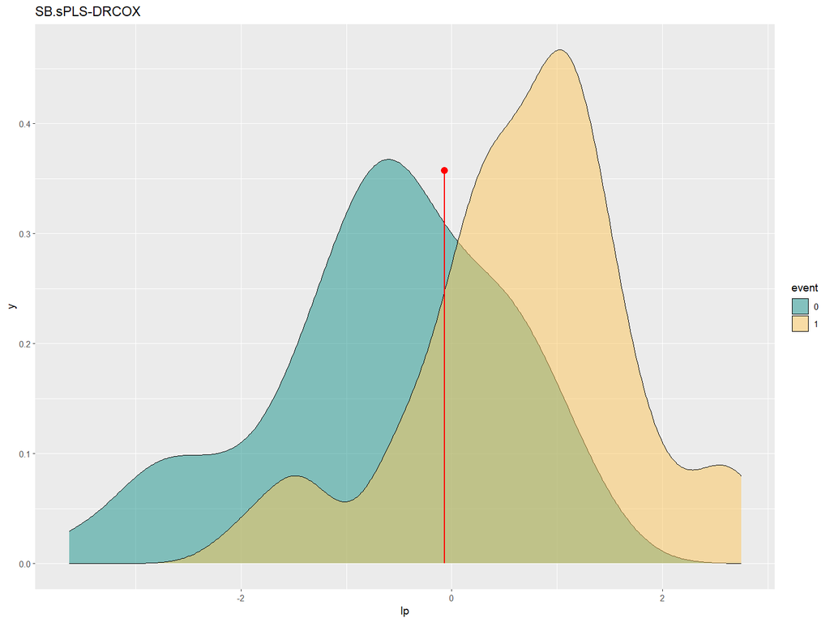

```r
pat_density
```

```r
pat_histogram <- plot_observation.eventHistogram(observation = new_pat,
                                                 model = lst_models$`SB.sPLS-DRCOX`,
                                                 time = NULL,
                                                 type = "lp")
```

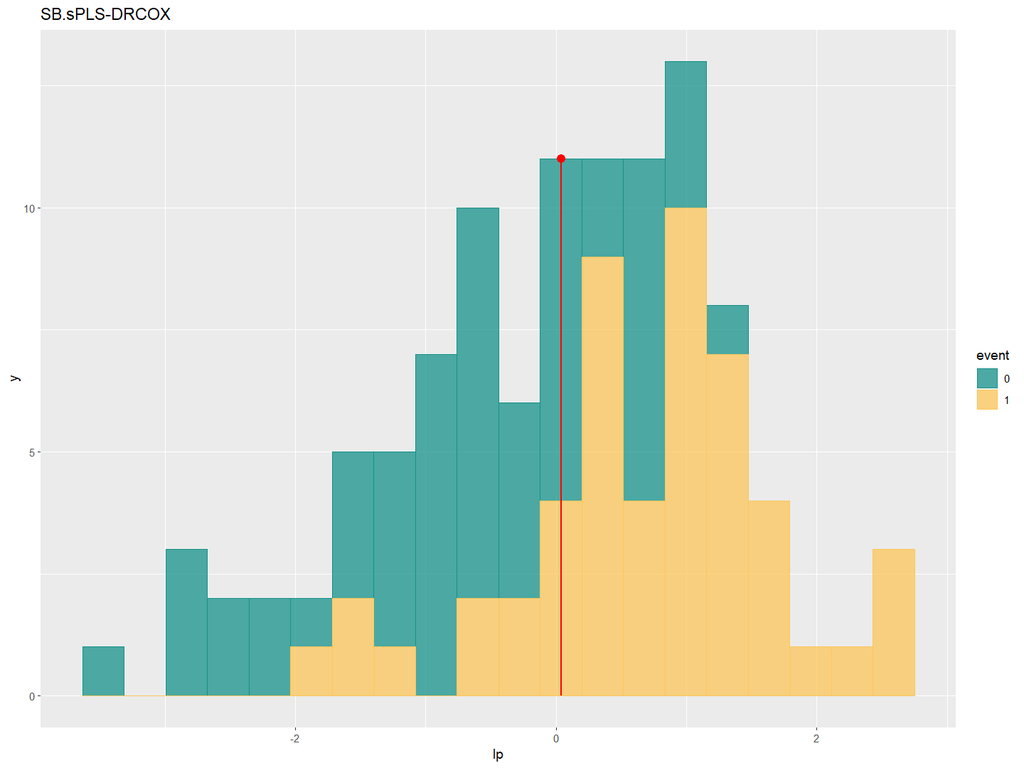

```r
pat_histogram
```

## COX compare patients

Furthermore, similar plots can be generated for multiple patients at the same time. For example, by selecting 5 patients, individual linear predictors for each variable and the final linear predictor using all the variables used in the survival model can be plotted.

As an idea, this function could also be used to study the same patient in different time points after receiving a treatment and study its own evolution related to the original variables.

```r
sub_X_test <- list()
for(b in names(X_test)){
  sub_X_test[[b]] <- X_test[[b]][1:5,]
}
```

```r
knitr::kable(Y_test[rownames(sub_X_test$proteomic),])
```

|  | time | event |
| --- | --- | --- |
| TCGA-A2-A0SV-01A | 825 | TRUE |
| TCGA-A2-A0YT-01A | 723 | TRUE |
| TCGA-BH-A1FB-01A | 3669 | TRUE |
| TCGA-D8-A1XC-01A | 377 | TRUE |
| TCGA-BH-A1EX-01A | 1508 | TRUE |

To generate the figure, the function `plot_LP.multipleObservations.list()` or `plot_LP.multipleObservations()` can be used.

```r
# lst_cox.comparison <- plot_LP.multipleObservations.list(lst_models = lst_models,
#                                                     new_observations = sub_X_test,
#                                                     error.bar = T, zero.rm = T, onlySig = T,
#                                                     alpha = 0.05, top = 5)

lst_cox.comparison <- plot_LP.multipleObservations(model = lst_models$`SB.sPLS-DRCOX`,
                                                   new_observations = sub_X_test,
                                                   error.bar = T, zero.rm = T, onlySig = T,
                                                   alpha = 0.05, top = 5)
```

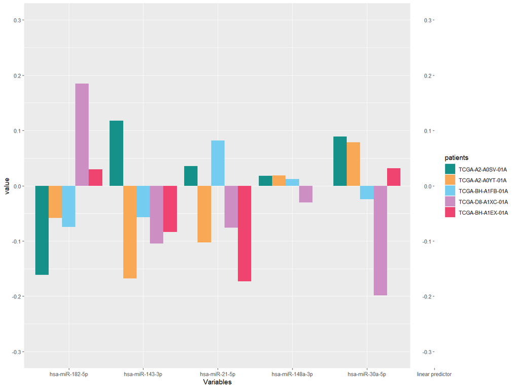

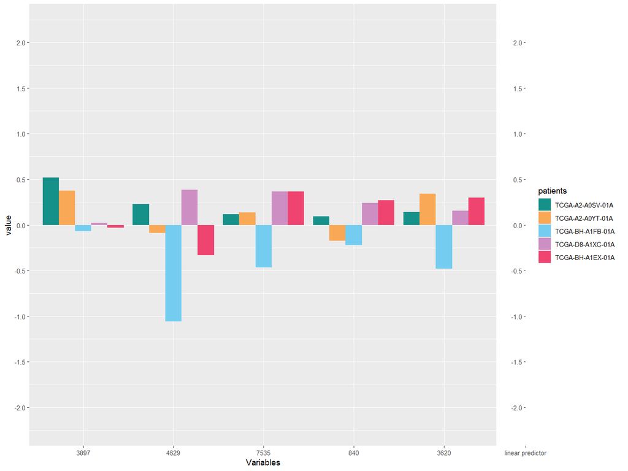

```r
# lst_cox.comparison$`iSB.sPLS-DRCOX`$plot
lst_cox.comparison$plot
```